# M7: Data Analysis Solutions

Arvon Clemons II

10/27/2020

# 1 CDAI and Treatment with Biologics

## 1.1 Numerical and Visual Descriptive Statistics

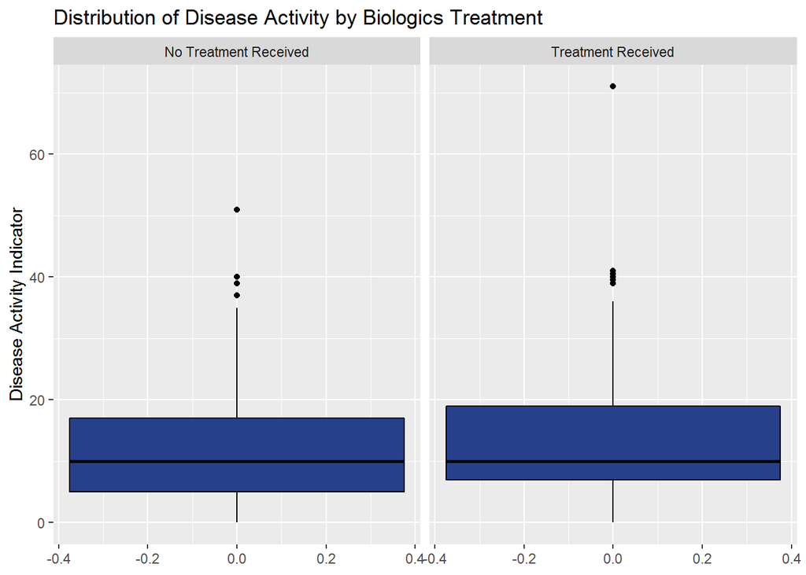

```r
p1 <- ra %>% filter(!is.na(Biologics) & !is.na(cdai)) %>% ggplot()

labels <- c(`0` = "No Treatment Received", `1` = "Treatment Received")  #factor labels

p1 + aes(y = cdai) + facet_wrap(. ~ Biologics, labeller = labeller(Biologics = labels)) + geom_boxplot(fill = "royalblue4",
    colour = "black", na.rm = T) + ggtitle("Distribution of Disease Activity by Biologics Treatment") +
    ylab("Disease Activity Indicator")
```

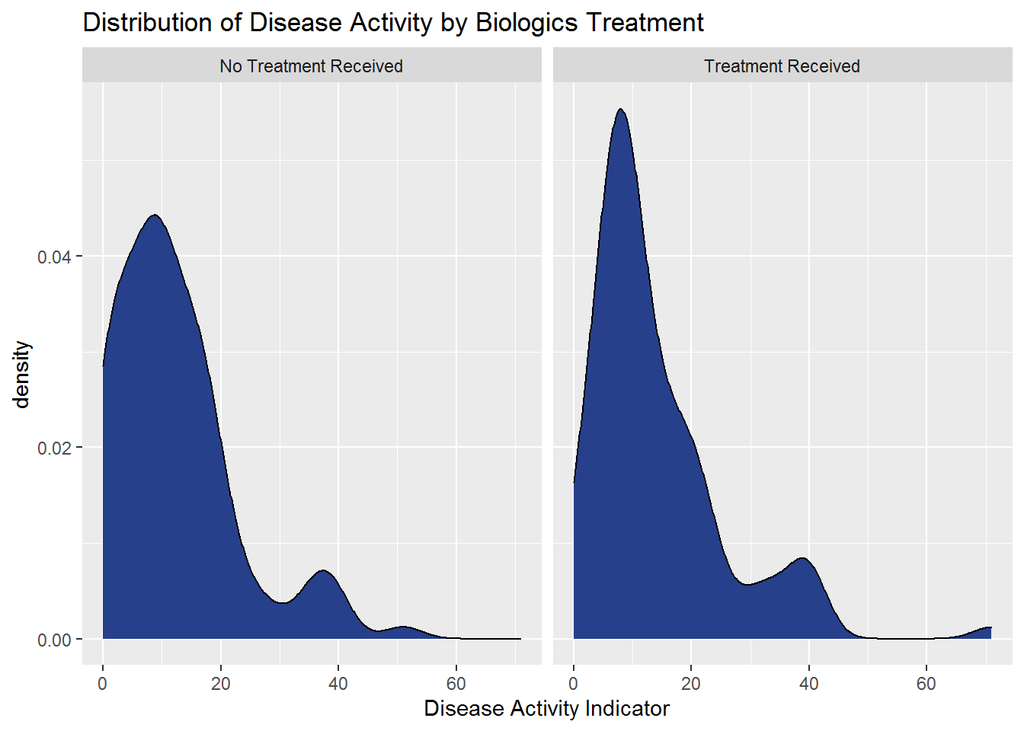

```r
p1 + aes(x = cdai) + facet_wrap(. ~ Biologics, labeller = labeller(Biologics = labels)) + geom_density(color = "black",
    fill = "royalblue4", na.rm = T) + ggtitle("Distribution of Disease Activity by Biologics Treatment") +
    xlab("Disease Activity Indicator")
```

```r
no_missing1 <- ra %>% select(Biologics, cdai) %>% drop_na()

numSum <- psych::describeBy(cdai ~ Biologics, data = no_missing1, fast = TRUE)
knitr::kable(numSum$`0`, caption = "No Treatment Received")
```

No Treatment Received

|  | vars | n | mean | sd | min | max | range | se |
| --- | --- | --- | --- | --- | --- | --- | --- | --- |
| X1 | 1 | 102 | 12.15686 | 10.45097 | 0 | 51 | 51 | 1.0348 |

```r
knitr::kable(numSum$`1`, caption = "Treatment Received")
```

Treatment Received

|  | vars | n | mean | sd | min | max | range | se |
| --- | --- | --- | --- | --- | --- | --- | --- | --- |
| X1 | 1 | 104 | 14.01923 | 11.60305 | 0 | 71 | 71 | 1.137772 |

## 1.2 Description of Wilcoxon Rank Sum

### 1.2.1 Hypotheses

$H_{0}$: The population median of clinical disease activity is equal between biological agent treatment. $H_{1}$: The population median of clinical disease activity is NOT equal between biological agent treatment.

### 1.2.2 Conditions Check

1. Two independent random samples
2. Population distributions similarly shaped

We assume the data comes from a random sample which participants have been randomly selected into either treatment group. We also assume that the distribution of treatments within the population are similarly shaped as is suggested by the graphs of the sample distribution.

### 1.2.3 Hypothesis Test

```r
(test1 <- wilcox.test(no_missing1$cdai ~ no_missing1$Biologics))
```

```
##
##  Wilcoxon rank sum test with continuity correction
##
## data:  no_missing1$cdai by no_missing1$Biologics
## W = 4830.5, p-value = 0.2684
## alternative hypothesis: true location shift is not equal to 0
```

### 1.2.4 Statistical Decision

From the above we receive a p-value of 0.2683774 which indicates the probability of getting the observed median assuming the null hypothesis is true. This is greater than our significance level of 0.05, indicating we do not have enough evidence and thus *FAIL TO REJECT* the null hypothesis.

### 1.2.5 Could we have used a parametric test?

The parametric analogue to the Wilcoxon Rank Sum test would be the two-sample T test. The conditions for that are: 1) Simple Random Sample of two populations 2) Both groups are independent 3) N1 > 30 and N2 > 30 or both outcomes normally distributed 4) Equal variance (determines which version to use)

The first two conditions are assumed, the third one we can check for below

```r
ra %>% filter(!is.na(Biologics) & !is.na(cdai)) %>% group_by(Biologics) %>% tally() %>% knitr::kable()
```

| Biologics | n |
| --- | --- |
| 0 | 102 |
| 1 | 104 |

Shows that we have at greater than 30 sample sizes for each group. Thus fulfilling all of the conditions for the two-sample T test.

## 1.3 Conclusion

The population median of clinical disease activity is equal between those who receive biologics for treatment and those who do not. This supports that there is no association between receiving biologics treatment and clinical disease activity.

# 2 Age and CDAI

## 2.1 Numerical and Visual Descriptive Statistics

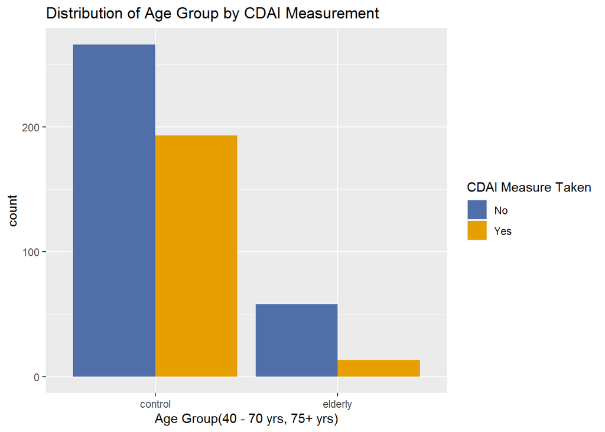

```r
p2 <- ra %>% filter(!is.na(AgeGp) & !is.na(CDAI_YN)) %>% mutate(AgeGp = if_else(AgeGp == "1", "control",
    "elderly"), CDAI_YN = if_else(CDAI_YN == "1", "No", "Yes"))

p2 %>% ggplot(aes(x = AgeGp, fill = CDAI_YN)) + geom_bar(position = "dodge") + scale_fill_manual(values = c("#506FA9",
    "#E69F00")) + ggtitle("Distribution of Age Group by CDAI Measurement") + xlab("Age Group(40 - 70 yrs, 75+ yrs)") +
    labs(fill = "CDAI Measure Taken")
```

```r
table(p2$AgeGp, p2$CDAI_YN) %>% knitr::kable(caption = "Table of Age Groups by CDAI Measurement")
```

Table of Age Groups by CDAI Measurement

|  | No | Yes |
| --- | --- | --- |
| control | 266 | 193 |
| elderly | 58 | 13 |

## 2.2 Description of Fisher’s Exact Test

### 2.2.1 Hypotheses

$H_{0}$: Age Group is NOT associated with getting a CDAI measurement. $H_{1}$: Age Group is associated with getting a CDAI measurement.

### 2.2.2 Conditions

The only condition is that our data is a simple random sample, which we assume is true such as in Part 1.

### 2.2.3 Hypothesis Test

```r
(test2 <- fisher.test(table(p2$AgeGp, p2$CDAI_YN)))
```

```
##
##  Fisher's Exact Test for Count Data
##
## data:  table(p2$AgeGp, p2$CDAI_YN)
## p-value = 0.0001205
## alternative hypothesis: true odds ratio is not equal to 1
## 95 percent confidence interval:
##  0.1511473 0.5914627
## sample estimates:
## odds ratio
##  0.3095428
```

### 2.2.4 Statistical Decision

From the above we observe a p-value of 1.205168810^{-4} which is the probability of getting the observed results under the assumption that the null hypothesis is true.Since this p-value is smaller than our significance level of 0.05, we assume that we have enough evidence to *REJECT* the null hypothesis.

### 2.2.5 Could we used $\chi^2$?

```r
t1 <- table(p2$AgeGp, p2$CDAI_YN)

tableOBS <- t1 %>% cbind(rowSums(t1)) %>% rbind(colSums(t1))
tableOBS[3, 3] <- sum(t1)

tableEXP <- matrix(NA, nrow = 2, ncol = 2, dimnames = list(c("control", "elderly"), c("No", "Yes")))

for (i in 1:2) {
    for (j in 1:2) {
        tableEXP[i, j] <- (tableOBS[i, 3] * tableOBS[3, j])/tableOBS[3, 3]
    }
}
tableEXP
```

```
##                No       Yes
## control 280.59623 178.40377
## elderly  43.40377  27.59623
```

The conditions for a chi-squared test of independence are the following: 1. The data come from a simple random sample 2. The expected count is at least 5 for each group

As can be seen above, the expected count for each group is at least 5. Thus we could have answered this same question using a $\chi^2$ Test for Independence.

## 2.3 Conclusion

We conclude that there **is** an association between Age Group and getting a CDAI measurement. Those who are 40 - 70 years of age are 0.3095428 times less likely to NOT get a measurement for Clinical Disease Activity than those who are 75+ years of age.

# 3 Age and Treatment with Biologics

## 3.1 Numerical and Visual Descriptive Statistics

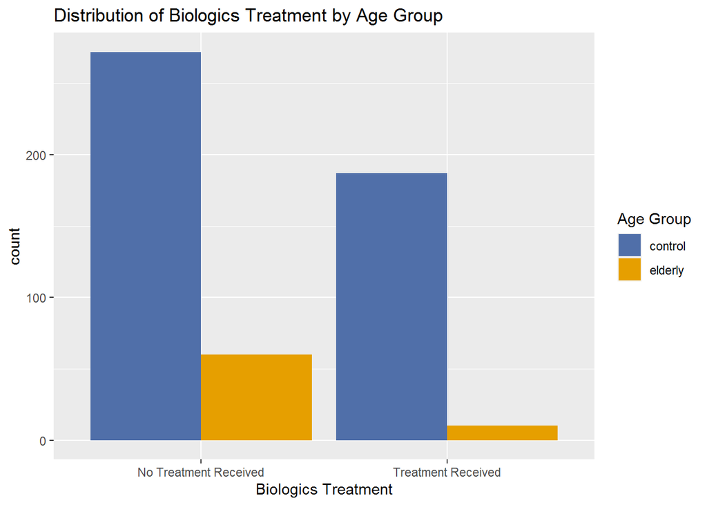

```r
p3 <- ra %>% filter(!is.na(Biologics) & !is.na(AgeGp)) %>% mutate(Biologics = if_else(Biologics == "0",
    "No Treatment Received", "Treatment Received"), AgeGp = if_else(AgeGp == "1", "control", "elderly"))

p3 %>% ggplot(aes(x = Biologics, fill = AgeGp)) + geom_bar(position = "dodge") + scale_fill_manual(values = c("#506FA9",
    "#E69F00")) + ggtitle("Distribution of Biologics Treatment by Age Group") + xlab("Biologics Treatment") +
    labs(fill = "Age Group")
```

```r
table(p3$Biologics, p3$AgeGp) %>% knitr::kable(caption = "Table of Biologics Treatment by Age Group")
```

Table of Biologics Treatment by Age Group

|  | control | elderly |
| --- | --- | --- |
| No Treatment Received | 272 | 60 |
| Treatment Received | 187 | 10 |

## 3.2 Description of Fisher’s Exact Test

### 3.2.1 Hypotheses

$H_{0}$: Receiving Biologics treatment is NOT associated with age group. $H_{1}$: Receiving Biologics treatment is associated with age group.

### 3.2.2 Conditions

The only condition is that our data is a simple random sample, which we assume is true such as in Part 1 & 2.

### 3.2.3 Hypothesis Test

```r
(test3 <- fisher.test(table(p3$Biologics, p3$AgeGp)))
```

```
##
##  Fisher's Exact Test for Count Data
##
## data:  table(p3$Biologics, p3$AgeGp)
## p-value = 8.891e-06
## alternative hypothesis: true odds ratio is not equal to 1
## 95 percent confidence interval:
##  0.1080309 0.4940959
## sample estimates:
## odds ratio
##   0.242972
```

### 3.2.4 Statistical Decision

From the above we observe a p-value of 8.891267210^{-6} which is the probability of getting the observed results under the assumption that the null hypothesis is true.Since this p-value is smaller than our significance level of 0.05, we assume that we have enough evidence to *REJECT* the null hypothesis.

### 3.2.5 Could we used $\chi^2$?

```r
t2 <- table(p3$Biologics, p3$AgeGp)

tableOBS <- t2 %>% cbind(rowSums(t2)) %>% rbind(colSums(t2))
tableOBS[3, 3] <- sum(t2)

tableEXP <- matrix(NA, nrow = 2, ncol = 2, dimnames = list(c("Not Received", "Received"), c("Control",
    "Elderly")))

for (i in 1:2) {
    for (j in 1:2) {
        tableEXP[i, j] <- (tableOBS[i, 3] * tableOBS[3, j])/tableOBS[3, 3]
    }
}
tableEXP
```

```
##               Control  Elderly
## Not Received 288.0681 43.93195
## Received     170.9319 26.06805
```

The conditions for a chi-squared test of homogeneity are the following: 1. The data come from a simple random sample 2. The expected count is at least 5 for each group

As can be seen above, the expected count for each group is at least 5. Thus we could have answered this same question using a $\chi^2$ Test for Homogeneity.

## 3.3 Conclusion

We conclude that there **is** an association between receiving Biologics treatment and age group. Those who did not receive treatment are 0.242972 times less likely to be 40 - 70 yrs of age than those who did receive treatment.

# 4 Comment on how your findings in Parts 2 & 3 might change the conclusions from Part 1.